# TS Assignment 3

Yunshuang Jiang

10/25/2020

(1 points) Question 1: Load the usgdp.rda dataset and split it into a training dataset (1947Q1 - 2005Q1) and a test dataset (2005Q2 - 2006Q1)

```r
library(tseries)
```

```r
library(ggplot2)
library(forecast)
library(fpp)
library(TSA)
usgdp <- window(usgdp)
```

```r
# Split the training and test sets
traindat = window(usgdp, start = c(1947,1), end = c(2005,1))
testdat = window(usgdp, start = c(2005,2), end = c(2006,1))
```

(5 points) Question 2: Plot the training dataset. Is the Box-Cox transformation necessary for this data?

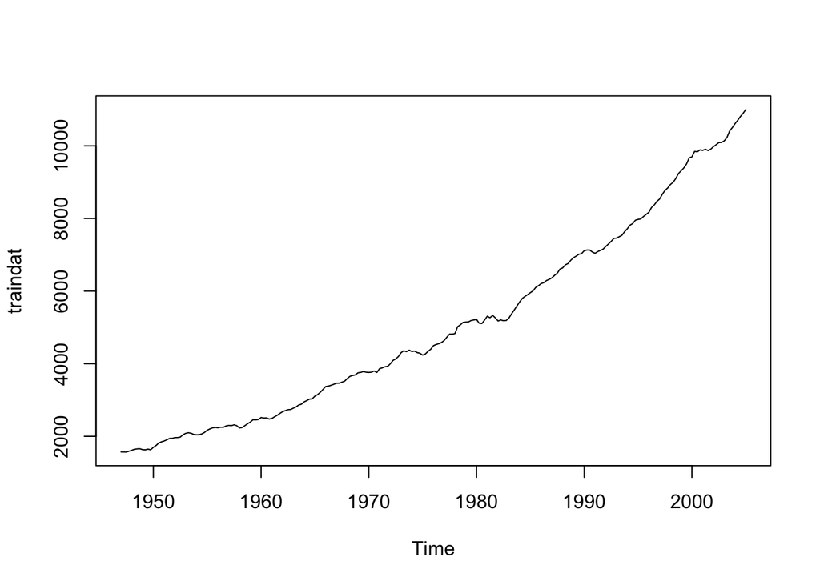

```r
ts.plot(traindat, type = 'l')
```

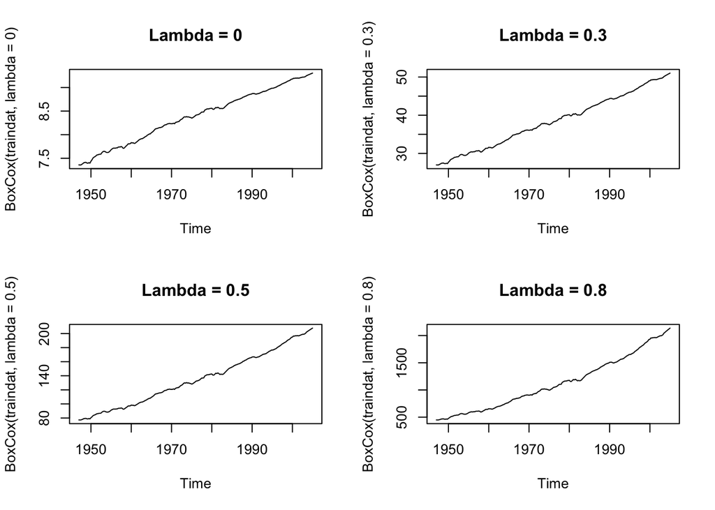

```r
# Try with different lambda
par(mfrow=c(2,2))
plot(BoxCox(traindat, lambda = 0), type = 'l', main = "Lambda = 0")
plot(BoxCox(traindat, lambda = 0.3), type = 'l', main = "Lambda = 0.3")
plot(BoxCox(traindat, lambda = 0.5), type = 'l', main = "Lambda = 0.5")
plot(BoxCox(traindat, lambda = 0.8), type = 'l', main = "Lambda = 0.8")
```

```r
BoxCox.lambda(traindat)
```

```
## [1] 0.3689656
```

We can see that the variation are very similar for all the levels of lambda we ploted above, therefore, box-cox transformation is not necessary to be applied to our training data.

(5 points) Question 3: Plot the 1st and 2nd order difference of the data. Apply KPSS Test for Stationarity to determine which difference order results in a stationary dataset.

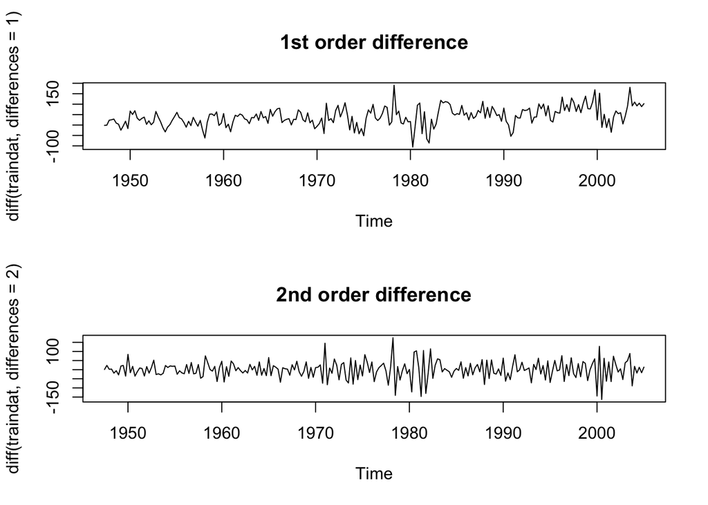

```r
par(mfrow=c(2,1))
plot(diff(traindat, differences = 1), main = "1st order difference")
plot(diff(traindat, differences = 2), main = "2nd order difference")
```

```r
# KPSS Test
kpss.test(diff(traindat, differences = 1))
```

```
##
##  KPSS Test for Level Stationarity
##
## data:  diff(traindat, differences = 1)
## KPSS Level = 1.6348, Truncation lag parameter = 4, p-value = 0.01
```

```r
kpss.test(diff(traindat, differences = 2))
```

```
##
##  KPSS Test for Level Stationarity
##
## data:  diff(traindat, differences = 2)
## KPSS Level = 0.0116, Truncation lag parameter = 4, p-value = 0.1
```

Based on the plot and KPSS test, the difference of order 2 results in a stationary dataset.

(5 points) Question 4: Fit a suitable ARIMA model to the training dataset using the auto.arima() function. Remember to transform the data first if necessary. Report the resulting 𝑝, 𝑑, 𝑞 and the coefficients values.

```r
(auto = auto.arima(traindat))
```

```
## Series: traindat
## ARIMA(2,2,2)
##
## Coefficients:
##           ar1     ar2      ma1      ma2
##       -0.1138  0.3059  -0.5829  -0.3710
## s.e.   0.2849  0.0895   0.2971   0.2844
##
## sigma^2 estimated as 1591:  log likelihood=-1178.16
## AIC=2366.32   AICc=2366.59   BIC=2383.53
```

The auto Arima resulting model has p = 2, d = 2, q = 2.

(5 points) Question 5: Compute the sample Extended ACF (EACF) and use the Arima() function to try some other plausible models by experimenting with the orders chosen. Limit your models to 𝑞, 𝑝 ≤ 2 and 𝑑 ≤ 2. Use the model summary() function to compare the Corrected Akaike information criterion (i.e., AICc) values (Note: Smaller values indicated better models).

```r
#' @export
eacf <-
function (z,ar.max=7,ma.max=13)
{
#
#  PROGRAMMED BY K.S. CHAN, DEPARTMENT OF STATISTICS AND ACTUARIAL SCIENCE,
#  UNIVERSITY OF IOWA.
#
#  DATE: 4/2001
#  Compute the extended sample acf (ESACF) for the time series stored in z.
#  The matrix of ESACF with the AR order up to ar.max and the MA order
#  up to ma.max is stored in the matrix EACFM.
#  The default values for NAR and NMA are 7 and 13 respectively.
#  Side effect of the eacf function:
#  The function prints a coded ESACF table with
#  significant values denoted by * and nosignificant values by 0, significance
#  level being 5%.
#
#  Output:
#   eacf=matrix of esacf
#   symbol=matrix of coded esacf
#

lag1<-function(z,lag=1){c(rep(NA,lag),z[1:(length(z)-lag)])}
reupm<-function(m1,nrow,ncol){
k<-ncol-1
m2<-NULL
for (i in 1:k){
i1<-i+1
work<-lag1(m1[,i])
work[1]<--1
temp<-m1[,i1]-work*m1[i1,i1]/m1[i,i]
temp[i1]<-0
m2<-cbind(m2,temp)
}
m2}
ceascf<-function(m,cov1,nar,ncol,count,ncov,z,zm){
result<-0*seq(1,nar+1)
result[1]<-cov1[ncov+count]
for (i in 1:nar) {
temp<-cbind(z[-(1:i)],zm[-(1:i),1:i])%*%c(1,-m[1:i,i])
result[i+1]<-acf(temp,plot=FALSE,lag.max=count,drop.lag.0=FALSE)$acf[count+1]
}
result
}

ar.max<-ar.max+1
ma.max<-ma.max+1
nar<-ar.max-1
nma<-ma.max
ncov<-nar+nma+2
nrow<-nar+nma+1
ncol<-nrow-1
z<-z-mean(z)
zm<-NULL
for(i in 1:nar) zm<-cbind(zm,lag1(z,lag=i))
cov1<-acf(z,lag.max=ncov,plot=FALSE,drop.lag.0=FALSE)$acf
cov1<-c(rev(cov1[-1]),cov1)
ncov<-ncov+1
m1<-matrix(0,ncol=ncol,nrow=nrow)
for(i in 1:ncol) m1[1:i,i]<-
ar.ols(z,order.max=i,aic=FALSE,demean=FALSE,intercept=FALSE)$ar
eacfm<-NULL
for (i in 1:nma) {
m2<-reupm(m1=m1,nrow=nrow,ncol=ncol)
ncol<-ncol-1
eacfm<-cbind(eacfm, ceascf(m2,cov1,nar,ncol,i,ncov,z,zm))
m1<-m2}
work<-1:(nar+1)
work<-length(z)-work+1
symbol<-NULL
for ( i in 1:nma) {
work<-work-1
symbol<-cbind(symbol,ifelse(abs(eacfm[,i])>2/work^.5, 'x','o'))}
rownames(symbol)<-0:(ar.max-1)
colnames(symbol)<-0:(ma.max-1)
cat('AR/MA\n')
print(symbol,quote=FALSE)
invisible(list(eacf=eacfm,ar.max=ar.max,ma.ma=ma.max,symbol=symbol))
}
```

```r
eacf(traindat)
```

```
## AR/MA
##   0 1 2 3 4 5 6 7 8 9 10 11 12 13
## 0 x x x x x x x x x x x  x  x  x
## 1 x x o o o o o x o o o  x  x  x
## 2 x o x o o o o x x o o  x  o  o
## 3 x x o o o o o x x o o  x  o  o
## 4 x x x o o o o o o o o  x  o  o
## 5 x x o o o o o o o o o  x  o  o
## 6 x x o o o o o o o o o  x  o  o
## 7 x x x o o o o o o o o  x  o  o
```

```r
#try different models
m1 = arima(traindat, order = c(1,1,1))
m1
```

```
##
## Call:
## arima(x = traindat, order = c(1, 1, 1))
##
## Coefficients:
##          ar1      ma1
##       0.9538  -0.6169
## s.e.  0.0289   0.0897
##
## sigma^2 estimated as 1706:  log likelihood = -1192.99,  aic = 2389.97
```

```r
m2 = arima(traindat, order = c(1,2,1))
m2
```

```
##
## Call:
## arima(x = traindat, order = c(1, 2, 1))
##
## Coefficients:
##          ar1      ma1
##       0.3026  -0.9597
## s.e.  0.0662   0.0180
##
## sigma^2 estimated as 1631:  log likelihood = -1183.09,  aic = 2370.18
```

```r
m3 = arima(traindat, order = c(2,1,2))
m3
```

```
##
## Call:
## arima(x = traindat, order = c(2, 1, 2))
##
## Coefficients:
##          ar1     ar2     ma1      ma2
##       0.1989  0.6988  0.1350  -0.3741
## s.e.  0.2031  0.1968  0.2184   0.1694
##
## sigma^2 estimated as 1697:  log likelihood = -1192.38,  aic = 2392.76
```

```r
m4 = arima(traindat, order = c(2,2,2))
m4
```

```
##
## Call:
## arima(x = traindat, order = c(2, 2, 2))
##
## Coefficients:
##           ar1     ar2      ma1      ma2
##       -0.1138  0.3059  -0.5829  -0.3710
## s.e.   0.2849  0.0895   0.2971   0.2844
##
## sigma^2 estimated as 1563:  log likelihood = -1178.16,  aic = 2364.32
```

Based on AIC, the 4th model is the best model.

(5 points) Question 6: Use the model chosen in Question 4 to forecast and plot the GDP forecasts with 80 and 95 % confidence levels for 2005Q2 - 2006Q1 (Test Period).

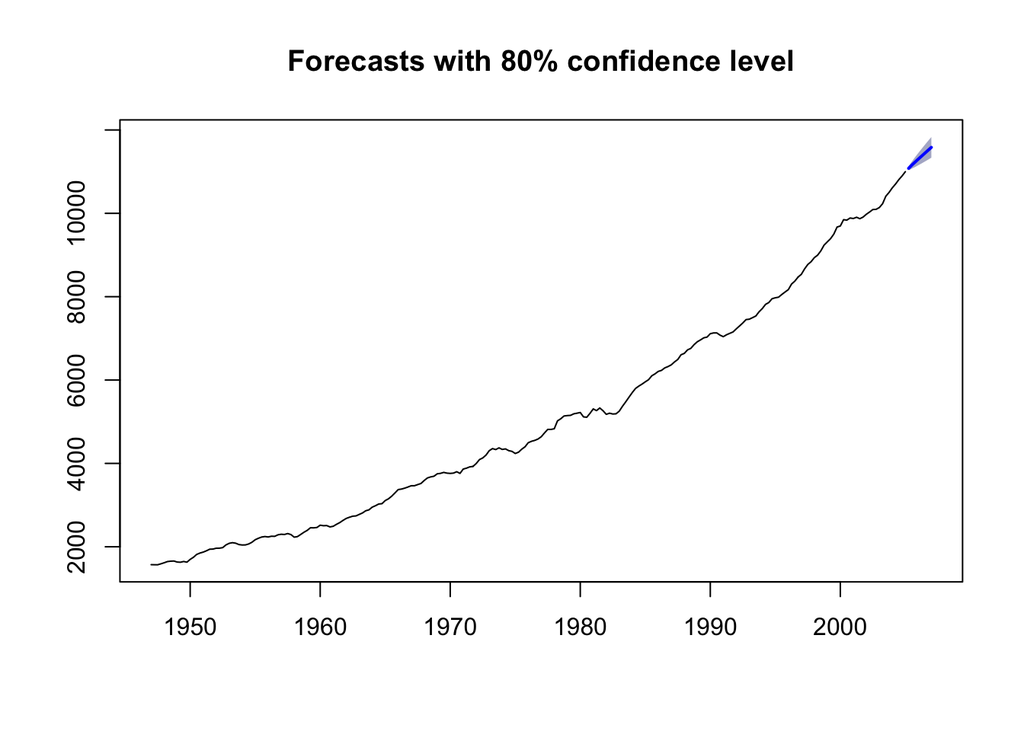

```r
# 80% confidence level
fore1 = forecast(auto, level = 80)
plot(forecast(auto,  level = 80), main = "Forecasts with 80% confidence level")
```

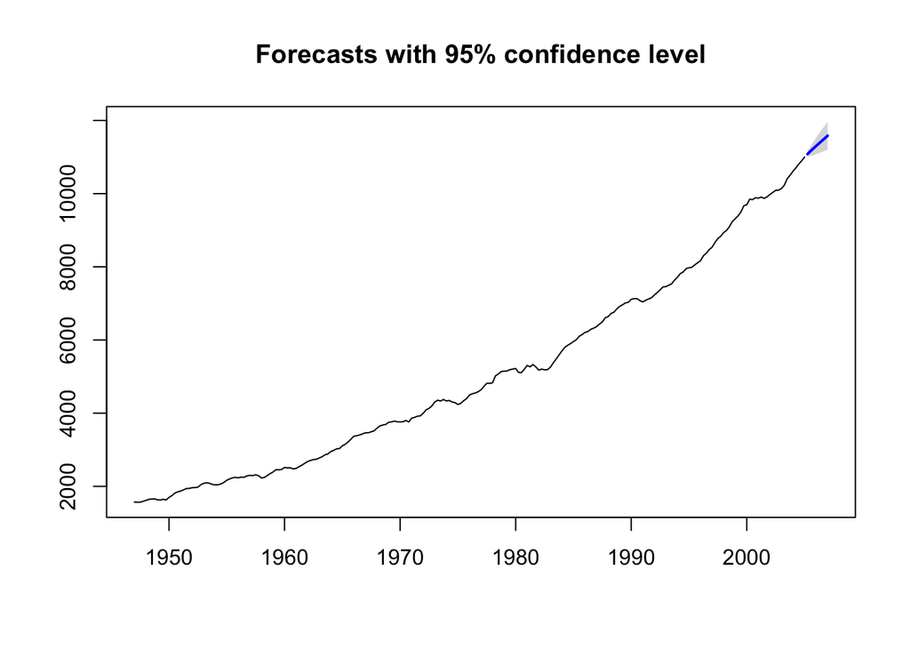

```r
# 95% confidence level
fore2 = forecast(auto, level = 95)
plot(forecast(auto, level = 95), main = "Forecasts with 95% confidence level")
```

(5 points) Question 7: Compare your forecasts with the actual values using error = actual - estimate and plot the errors. (Note: Use the forecast $mean element for the forecast estimate)

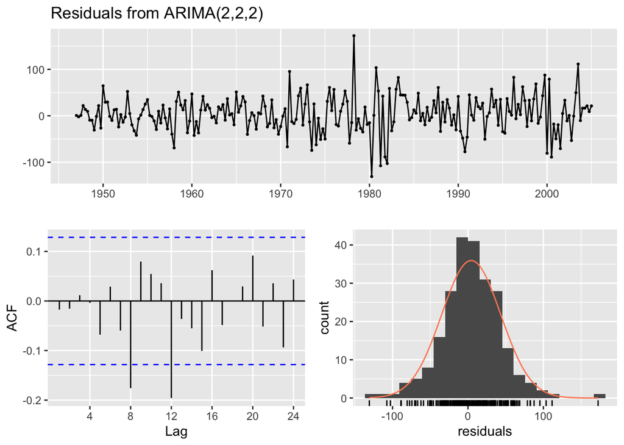

```
##
##  Ljung-Box test
##
## data:  Residuals from ARIMA(2,2,2)
## Q* = 9.8604, df = 4, p-value = 0.04285
##
## Model df: 4.   Total lags used: 8
```

```r
checkresiduals(auto)
```

```r
# 80% confidence level
error1 = testdat - fore1$mean
error1
```

```
##           Qtr1      Qtr2      Qtr3      Qtr4
## 2005            10.16263  44.58518  18.65855
## 2006 101.58798
```

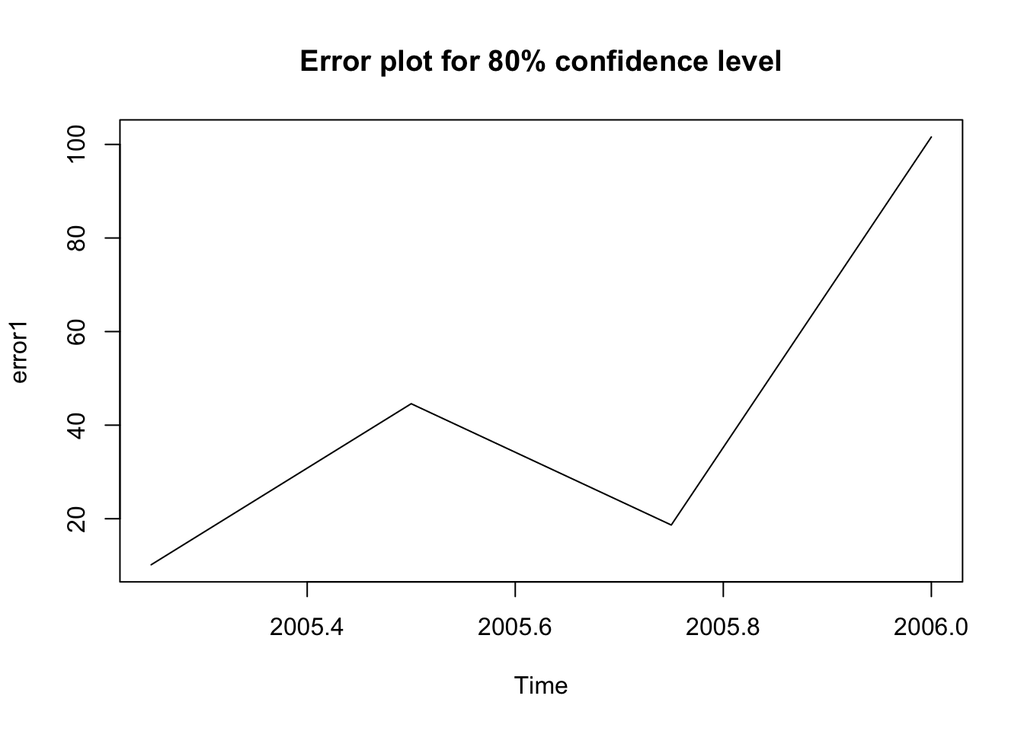

```r
plot(error1, main = "Error plot for 80% confidence level")
```

```r
# For 95% confidence level
error2 = testdat - fore2$mean
error2
```

```
##           Qtr1      Qtr2      Qtr3      Qtr4
## 2005            10.16263  44.58518  18.65855
## 2006 101.58798
```

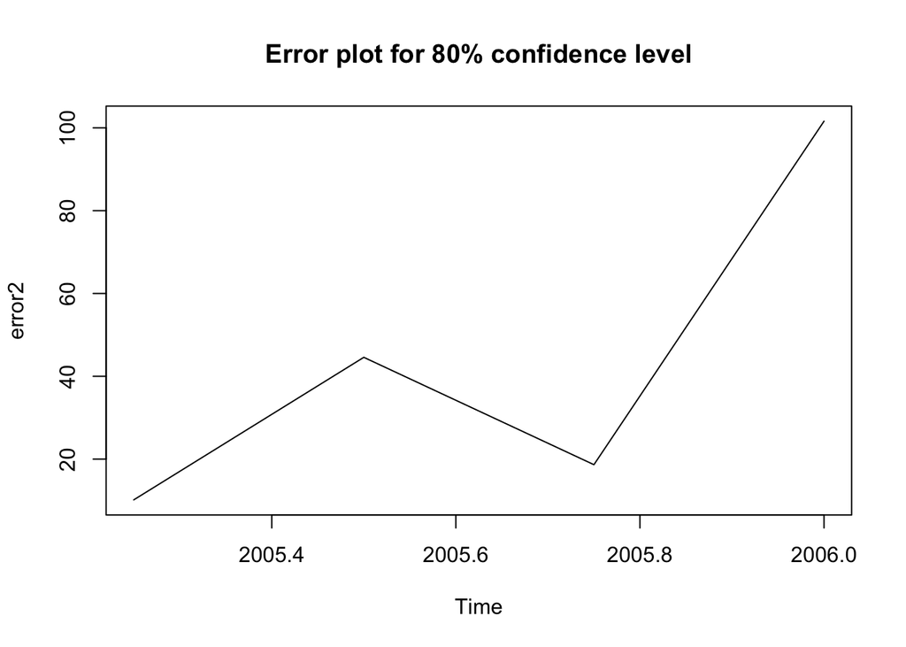

```r
plot(error2, main = "Error plot for 80% confidence level")
```

(5 points) Question 8: Calculate the sum of squared error.

```r
# For 80% confidence level
sumsquared1 = sum((testdat-fore1$mean)^2)
sumsquared1
```

```
## [1] 12759.38
```

```r
# For 95% confidence level
sumsquared2 = sum((testdat-fore2$mean)^2)
sumsquared2
```

```
## [1] 12759.38
```